# DATA 511 Project (R Notebook)

This project is for DATA 511 - Big Data Strategy for Samford University.We have been tasked to collect data on a topic we are curious about, compile data, and produce visualization to find trends in the data.

I am looking into email response times from my company, Jacksonville State.

I first needed to import all the packages needed for this project.

Import the whole dataset from the project.

```r
email_response <- read_csv("hw5_data.csv")
```

Calculating the correlation coefficient between my response time and the response time

```r
email_response$mytime_num <- as.numeric(email_response$my_response_time)
email_response$responsetime_num <-
  as.numeric(email_response$return_response_time)
response_corr <- cor(email_response$mytime_num, email_response$responsetime_num)
response_corr
```

```
## [1] 0.1081633
```

The number above shows us that there is a very slight positive correlation bewteen my response time and the respondents repsonse time. This becomes very evident when looking a scatter plot with the data.

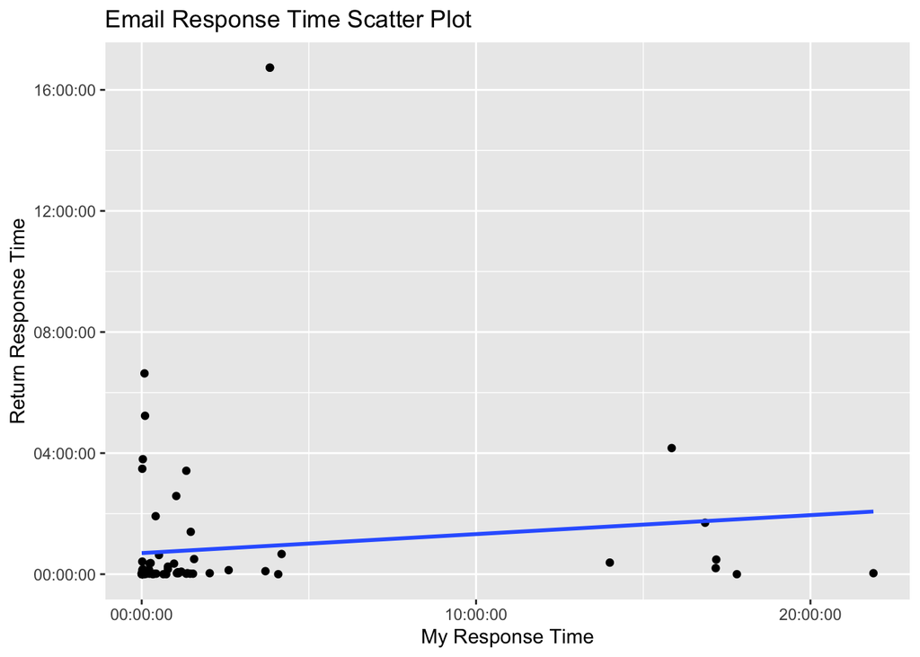

```r
email_viz01 <- ggplot(data=email_response, aes(x=my_response_time,
                                             y=return_response_time)) +
  geom_point() +
  geom_smooth(method=lm,
              se=FALSE) +
  xlab('My Response Time') +
  ylab('Return Response Time') +
  ggtitle("Email Response Time Scatter Plot")

email_viz01
```

We can break it down even further to examine if there was a stronger correlation between my response time while sending messages through Microdot Outlook or through Microsoft Teams.

```r
mt_messages <- email_response %>% filter(service == "MT")
mt_messages$mytime_num <- as.numeric(mt_messages$my_response_time)
mt_messages$responsetime_num <-
  as.numeric(mt_messages$return_response_time)
mt_response_corr <- cor(mt_messages$mytime_num, mt_messages$responsetime_num)
mt_response_corr
```

```
## [1] -0.02070269
```

We see from the number above that there is actually a slightly negative correlation in response time for conversations taking place through Microsoft Teams.

```r
mo_messages <- email_response %>% filter(service == "MO")
mo_messages$mytime_num <- as.numeric(mo_messages$my_response_time)
mo_messages$responsetime_num <-
  as.numeric(mo_messages$return_response_time)
mo_response_corr <- cor(mo_messages$mytime_num, mo_messages$responsetime_num)
mo_response_corr
```

```
## [1] 0.1117856
```

Scatter plot for data showing differences in Microsoft Outlook and Microsoft Teams response times

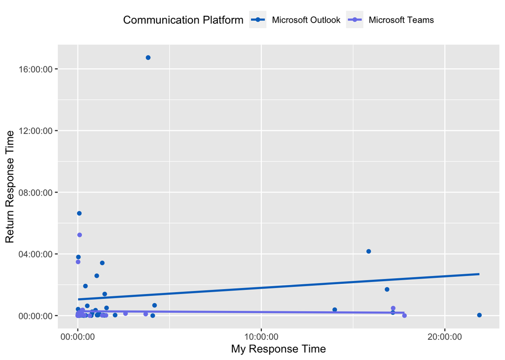

```r
email_viz <- ggplot(data=email_response, aes(x=my_response_time,
                                             y=return_response_time,
                                             color=service)) +
  geom_point() +
  geom_smooth(method=lm,
              se=FALSE) +
  xlab('My Response Time') +
  ylab('Return Response Time') +
  scale_colour_manual(values=c("#0072C6", "#7B83EB"),
                        name="Communication Platform",
                        breaks=c("MO", "MT"),
                        labels=c("Microsoft Outlook", "Microsoft Teams")) +
  theme(legend.position = "top")

email_viz
```

Importing data for the times emails were received

```r
received_times <- read_csv("email_times.csv")
```

Building out a histograms to show when people sent emails the most

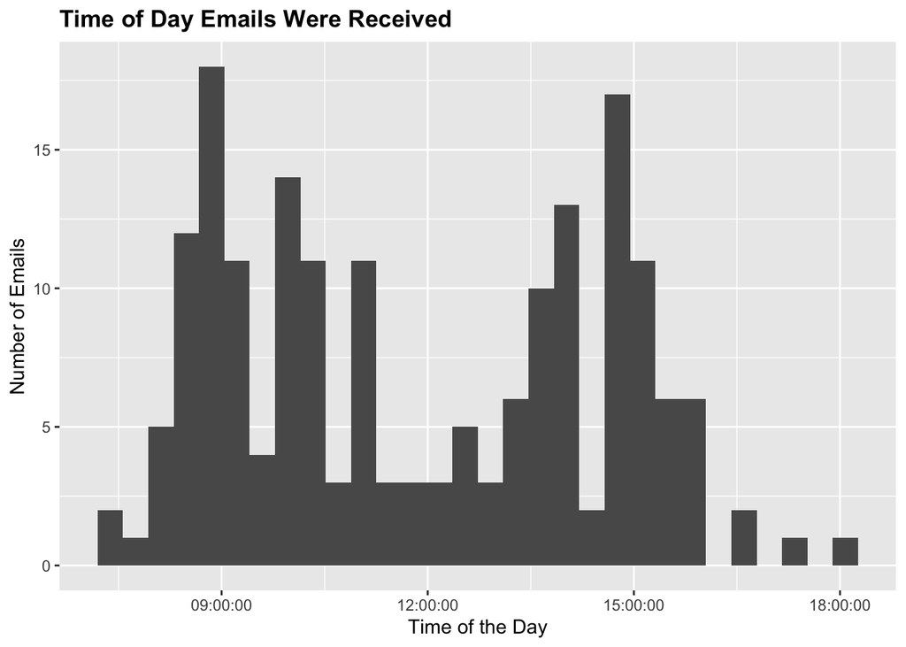

```r
m <- mean(received_times$times)
std <- sqrt(var(received_times$times))
resp_viz <- ggplot(data = received_times, aes(x=times)) +
  geom_histogram() +
  xlab("Time of the Day") +
  ylab("Number of Emails") +
  ggtitle("Time of Day Emails Were Received") +
  theme(plot.title = element_text(lineheight=.8, face="bold"))
resp_viz
```